# R Notebook

Include packages for datasets and functions

```r
library(MASS)
library(ISLR)
```

Can call help on dataset to read documentation See dataframe’s first few rows

```r
?Boston
head(Boston)
```

|  | crim | zn | indus | chas | nox | rm | age | dis | rad | tax | ptratio | black | lstat | medv |
| --- | --- | --- | --- | --- | --- | --- | --- | --- | --- | --- | --- | --- | --- | --- |
| 1 | 0.00632 | 18 | 2.31 | 0 | 0.538 | 6.575 | 65.2 | 4.0900 | 1 | 296 | 15.3 | 396.90 | 4.98 | 24.0 |
| 2 | 0.02731 | 0 | 7.07 | 0 | 0.469 | 6.421 | 78.9 | 4.9671 | 2 | 242 | 17.8 | 396.90 | 9.14 | 21.6 |
| 3 | 0.02729 | 0 | 7.07 | 0 | 0.469 | 7.185 | 61.1 | 4.9671 | 2 | 242 | 17.8 | 392.83 | 4.03 | 34.7 |
| 4 | 0.03237 | 0 | 2.18 | 0 | 0.458 | 6.998 | 45.8 | 6.0622 | 3 | 222 | 18.7 | 394.63 | 2.94 | 33.4 |
| 5 | 0.06905 | 0 | 2.18 | 0 | 0.458 | 7.147 | 54.2 | 6.0622 | 3 | 222 | 18.7 | 396.90 | 5.33 | 36.2 |
| 6 | 0.02985 | 0 | 2.18 | 0 | 0.458 | 6.430 | 58.7 | 6.0622 | 3 | 222 | 18.7 | 394.12 | 5.21 | 28.7 |

Housing Values in Suburbs of Boston Description The Boston data frame has 506 rows and 14 columns.

Usage Boston Format This data frame contains the following columns:

crim per capita crime rate by town.

zn proportion of residential land zoned for lots over 25,000 sq.ft.

indus proportion of non-retail business acres per town.

chas Charles River dummy variable (= 1 if tract bounds river; 0 otherwise).

nox nitrogen oxides concentration (parts per 10 million).

rm average number of rooms per dwelling.

age proportion of owner-occupied units built prior to 1940.

dis weighted mean of distances to five Boston employment centres.

rad index of accessibility to radial highways.

tax full-value property-tax rate per $10,000.

ptratio pupil-teacher ratio by town.

black 1000(Bk - 0.63)^2 where Bk is the proportion of blacks by town.

lstat lower status of the population (percent).

medv median value of owner-occupied homes in $1000s.

```r
names(Boston)
```

```
 [1] "crim"    "zn"      "indus"   "chas"    "nox"
 [6] "rm"      "age"     "dis"     "rad"     "tax"
[11] "ptratio" "black"   "lstat"   "medv"
```

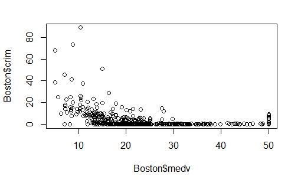

```r
plot(Boston$medv,Boston$crim)
```

Exploratory analysis : see all correlations

```r
cor(Boston)
```

```
               crim          zn       indus         chas
crim     1.00000000 -0.20046922  0.40658341 -0.055891582
zn      -0.20046922  1.00000000 -0.53382819 -0.042696719
indus    0.40658341 -0.53382819  1.00000000  0.062938027
chas    -0.05589158 -0.04269672  0.06293803  1.000000000
nox      0.42097171 -0.51660371  0.76365145  0.091202807
rm      -0.21924670  0.31199059 -0.39167585  0.091251225
age      0.35273425 -0.56953734  0.64477851  0.086517774
dis     -0.37967009  0.66440822 -0.70802699 -0.099175780
rad      0.62550515 -0.31194783  0.59512927 -0.007368241
tax      0.58276431 -0.31456332  0.72076018 -0.035586518
ptratio  0.28994558 -0.39167855  0.38324756 -0.121515174
black   -0.38506394  0.17552032 -0.35697654  0.048788485
lstat    0.45562148 -0.41299457  0.60379972 -0.053929298
medv    -0.38830461  0.36044534 -0.48372516  0.175260177
                nox          rm         age         dis
crim     0.42097171 -0.21924670  0.35273425 -0.37967009
zn      -0.51660371  0.31199059 -0.56953734  0.66440822
indus    0.76365145 -0.39167585  0.64477851 -0.70802699
chas     0.09120281  0.09125123  0.08651777 -0.09917578
nox      1.00000000 -0.30218819  0.73147010 -0.76923011
rm      -0.30218819  1.00000000 -0.24026493  0.20524621
age      0.73147010 -0.24026493  1.00000000 -0.74788054
dis     -0.76923011  0.20524621 -0.74788054  1.00000000
rad      0.61144056 -0.20984667  0.45602245 -0.49458793
tax      0.66802320 -0.29204783  0.50645559 -0.53443158
ptratio  0.18893268 -0.35550149  0.26151501 -0.23247054
black   -0.38005064  0.12806864 -0.27353398  0.29151167
lstat    0.59087892 -0.61380827  0.60233853 -0.49699583
medv    -0.42732077  0.69535995 -0.37695457  0.24992873
                 rad         tax    ptratio       black
crim     0.625505145  0.58276431  0.2899456 -0.38506394
zn      -0.311947826 -0.31456332 -0.3916785  0.17552032
indus    0.595129275  0.72076018  0.3832476 -0.35697654
chas    -0.007368241 -0.03558652 -0.1215152  0.04878848
nox      0.611440563  0.66802320  0.1889327 -0.38005064
rm      -0.209846668 -0.29204783 -0.3555015  0.12806864
age      0.456022452  0.50645559  0.2615150 -0.27353398
dis     -0.494587930 -0.53443158 -0.2324705  0.29151167
rad      1.000000000  0.91022819  0.4647412 -0.44441282
tax      0.910228189  1.00000000  0.4608530 -0.44180801
ptratio  0.464741179  0.46085304  1.0000000 -0.17738330
black   -0.444412816 -0.44180801 -0.1773833  1.00000000
lstat    0.488676335  0.54399341  0.3740443 -0.36608690
medv    -0.381626231 -0.46853593 -0.5077867  0.33346082
             lstat       medv
crim     0.4556215 -0.3883046
zn      -0.4129946  0.3604453
indus    0.6037997 -0.4837252
chas    -0.0539293  0.1752602
nox      0.5908789 -0.4273208
rm      -0.6138083  0.6953599
age      0.6023385 -0.3769546
dis     -0.4969958  0.2499287
rad      0.4886763 -0.3816262
tax      0.5439934 -0.4685359
ptratio  0.3740443 -0.5077867
black   -0.3660869  0.3334608
lstat    1.0000000 -0.7376627
medv    -0.7376627  1.0000000
```

High correlations between: indus dis indus tax nox age dis tax rad

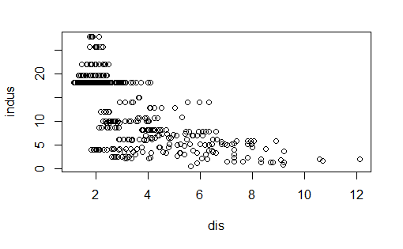

```r
plot( dis,indus)
```

Insights Expected There is higher nox where industry proportion is higher As mean distance from employment center (dis increases), porportion of industries decreases we can say that employment is mainly in industries only Tax is higher where indus is higher nox is higher where dis is lower

Commence model fitting:

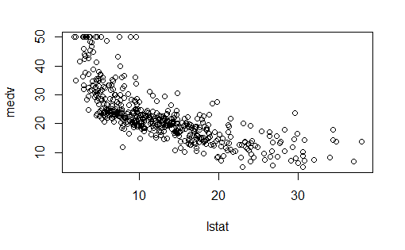

```r
plot(medv~lstat,Boston)
```

```r
fit1 = lm(medv~lstat,data=Boston)
fit1
```

```
Call:
lm(formula = medv ~ lstat, data = Boston)

Coefficients:
(Intercept)        lstat
      34.55        -0.95
```

```r
summary(fit1)
```

```
Call:
lm(formula = medv ~ lstat, data = Boston)

Residuals:
    Min      1Q  Median      3Q     Max
-15.168  -3.990  -1.318   2.034  24.500

Coefficients:
            Estimate Std. Error t value Pr(>|t|)
(Intercept) 34.55384    0.56263   61.41   <2e-16 ***
lstat       -0.95005    0.03873  -24.53   <2e-16 ***
---
Signif. codes:
0 ‘***’ 0.001 ‘**’ 0.01 ‘*’ 0.05 ‘.’ 0.1 ‘ ’ 1

Residual standard error: 6.216 on 504 degrees of freedom
Multiple R-squared:  0.5441,    Adjusted R-squared:  0.5432
F-statistic: 601.6 on 1 and 504 DF,  p-value: < 2.2e-16
```

```r
cor(medv,lstat)
```

```
[1] -0.7376627
```

```r
sqrt(0.5441)
```

```
[1] 0.7376313
```

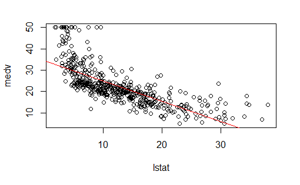

```r
plot(medv~lstat,Boston)
abline(fit1,col="red")
```

```r
names(fit1)
```

```
 [1] "coefficients"  "residuals"     "effects"
 [4] "rank"          "fitted.values" "assign"
 [7] "qr"            "df.residual"   "xlevels"
[10] "call"          "terms"         "model"
```

```r
confint(fit1)
```

```
                2.5 %     97.5 %
(Intercept) 33.448457 35.6592247
lstat       -1.026148 -0.8739505
```

```r
predict(fit1,data.frame(lstat=c(5,10,15)),interval ="confidence")
```

```
       fit      lwr      upr
1 29.80359 29.00741 30.59978
2 25.05335 24.47413 25.63256
3 20.30310 19.73159 20.87461
```

Moving on to multiple variable linear regression,

```r
fit2 = lm(medv~lstat+age,data=Boston)
summary(fit2)
```

```
Call:
lm(formula = medv ~ lstat + age, data = Boston)

Residuals:
    Min      1Q  Median      3Q     Max
-15.981  -3.978  -1.283   1.968  23.158

Coefficients:
            Estimate Std. Error t value Pr(>|t|)
(Intercept) 33.22276    0.73085  45.458  < 2e-16 ***
lstat       -1.03207    0.04819 -21.416  < 2e-16 ***
age          0.03454    0.01223   2.826  0.00491 **
---
Signif. codes:
0 ‘***’ 0.001 ‘**’ 0.01 ‘*’ 0.05 ‘.’ 0.1 ‘ ’ 1

Residual standard error: 6.173 on 503 degrees of freedom
Multiple R-squared:  0.5513,    Adjusted R-squared:  0.5495
F-statistic:   309 on 2 and 503 DF,  p-value: < 2.2e-16
```

```r
fit3 = lm(medv~.,data=Boston)
summary(fit3)
```

```
Call:
lm(formula = medv ~ ., data = Boston)

Residuals:
    Min      1Q  Median      3Q     Max
-15.595  -2.730  -0.518   1.777  26.199

Coefficients:
              Estimate Std. Error t value Pr(>|t|)
(Intercept)  3.646e+01  5.103e+00   7.144 3.28e-12 ***
crim        -1.080e-01  3.286e-02  -3.287 0.001087 **
zn           4.642e-02  1.373e-02   3.382 0.000778 ***
indus        2.056e-02  6.150e-02   0.334 0.738288
chas         2.687e+00  8.616e-01   3.118 0.001925 **
nox         -1.777e+01  3.820e+00  -4.651 4.25e-06 ***
rm           3.810e+00  4.179e-01   9.116  < 2e-16 ***
age          6.922e-04  1.321e-02   0.052 0.958229
dis         -1.476e+00  1.995e-01  -7.398 6.01e-13 ***
rad          3.060e-01  6.635e-02   4.613 5.07e-06 ***
tax         -1.233e-02  3.760e-03  -3.280 0.001112 **
ptratio     -9.527e-01  1.308e-01  -7.283 1.31e-12 ***
black        9.312e-03  2.686e-03   3.467 0.000573 ***
lstat       -5.248e-01  5.072e-02 -10.347  < 2e-16 ***
---
Signif. codes:
0 ‘***’ 0.001 ‘**’ 0.01 ‘*’ 0.05 ‘.’ 0.1 ‘ ’ 1

Residual standard error: 4.745 on 492 degrees of freedom
Multiple R-squared:  0.7406,    Adjusted R-squared:  0.7338
F-statistic: 108.1 on 13 and 492 DF,  p-value: < 2.2e-16
```

R squared jumped from 50% to 70% when all variables were included. Also note that when just lstat and age were present in model both were significant. However after including all variables, lstat remains significant but age becomes insignficant. Meaning that, some other variable is explaining the variance instead of age, implying that some variable is correlated with age. Some graphs of current model:

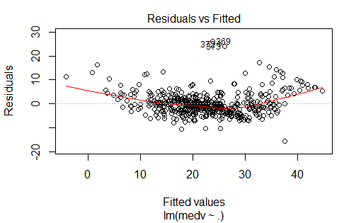

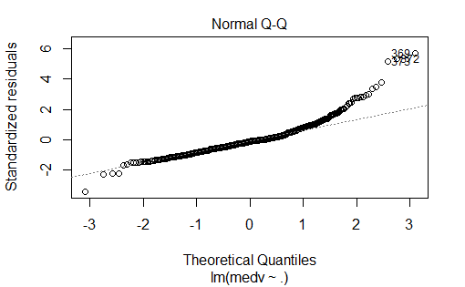

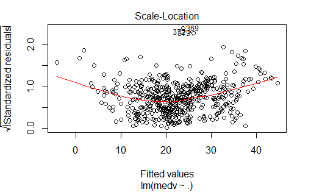

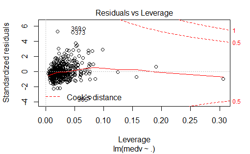

```r
par(mfrow=c(1,1))
plot(fit3)
```

Looking at the residuals vs fitted graph, we can see that there is non linearity(Explain?) Remove age and indus as they were not siginificant

```r
fit4 = update(fit3,~.-age-indus)
summary(fit4)
```

```
Call:
lm(formula = medv ~ crim + zn + chas + nox + rm + dis + rad +
    tax + ptratio + black + lstat, data = Boston)

Residuals:
     Min       1Q   Median       3Q      Max
-15.5984  -2.7386  -0.5046   1.7273  26.2373

Coefficients:
              Estimate Std. Error t value Pr(>|t|)
(Intercept)  36.341145   5.067492   7.171 2.73e-12 ***
crim         -0.108413   0.032779  -3.307 0.001010 **
zn            0.045845   0.013523   3.390 0.000754 ***
chas          2.718716   0.854240   3.183 0.001551 **
nox         -17.376023   3.535243  -4.915 1.21e-06 ***
rm            3.801579   0.406316   9.356  < 2e-16 ***
dis          -1.492711   0.185731  -8.037 6.84e-15 ***
rad           0.299608   0.063402   4.726 3.00e-06 ***
tax          -0.011778   0.003372  -3.493 0.000521 ***
ptratio      -0.946525   0.129066  -7.334 9.24e-13 ***
black         0.009291   0.002674   3.475 0.000557 ***
lstat        -0.522553   0.047424 -11.019  < 2e-16 ***
---
Signif. codes:
0 ‘***’ 0.001 ‘**’ 0.01 ‘*’ 0.05 ‘.’ 0.1 ‘ ’ 1

Residual standard error: 4.736 on 494 degrees of freedom
Multiple R-squared:  0.7406,    Adjusted R-squared:  0.7348
F-statistic: 128.2 on 11 and 494 DF,  p-value: < 2.2e-16
```

```r
fit5 = lm(medv~lstat*age,Boston) ##interaction with main effects included
summary(fit5)
```

```
Call:
lm(formula = medv ~ lstat * age, data = Boston)

Residuals:
    Min      1Q  Median      3Q     Max
-15.806  -4.045  -1.333   2.085  27.552

Coefficients:
              Estimate Std. Error t value Pr(>|t|)
(Intercept) 36.0885359  1.4698355  24.553  < 2e-16 ***
lstat       -1.3921168  0.1674555  -8.313 8.78e-16 ***
age         -0.0007209  0.0198792  -0.036   0.9711
lstat:age    0.0041560  0.0018518   2.244   0.0252 *
---
Signif. codes:
0 ‘***’ 0.001 ‘**’ 0.01 ‘*’ 0.05 ‘.’ 0.1 ‘ ’ 1

Residual standard error: 6.149 on 502 degrees of freedom
Multiple R-squared:  0.5557,    Adjusted R-squared:  0.5531
F-statistic: 209.3 on 3 and 502 DF,  p-value: < 2.2e-16
```

As we can see, lstat is still significant, but the lstat-age interaction is also singificant

Now introducing non linear term of power 2, this is how it looks

```r
fit6 =lm(medv~lstat+I(lstat^2),Boston); summary(fit6);
```

```
Call:
lm(formula = medv ~ lstat + I(lstat^2), data = Boston)

Residuals:
     Min       1Q   Median       3Q      Max
-15.2834  -3.8313  -0.5295   2.3095  25.4148

Coefficients:
             Estimate Std. Error t value Pr(>|t|)
(Intercept) 42.862007   0.872084   49.15   <2e-16 ***
lstat       -2.332821   0.123803  -18.84   <2e-16 ***
I(lstat^2)   0.043547   0.003745   11.63   <2e-16 ***
---
Signif. codes:
0 ‘***’ 0.001 ‘**’ 0.01 ‘*’ 0.05 ‘.’ 0.1 ‘ ’ 1

Residual standard error: 5.524 on 503 degrees of freedom
Multiple R-squared:  0.6407,    Adjusted R-squared:  0.6393
F-statistic: 448.5 on 2 and 503 DF,  p-value: < 2.2e-16
```

As this model is non linear we can’t use abline to plot the model points. Hence we use points function.

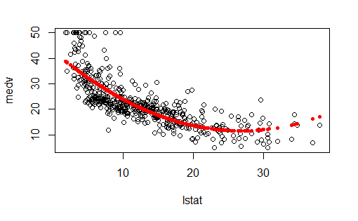

```r
plot(medv~lstat)
points(lstat,fitted(fit6),col="red",pch=20)
```

Another way to model nonlinearly is using poly function

```r
fit7=lm(medv~poly(lstat,4))
summary(fit7)
```

```
Call:
lm(formula = medv ~ poly(lstat, 4))

Residuals:
    Min      1Q  Median      3Q     Max
-13.563  -3.180  -0.632   2.283  27.181

Coefficients:
                 Estimate Std. Error t value Pr(>|t|)
(Intercept)       22.5328     0.2347  95.995  < 2e-16 ***
poly(lstat, 4)1 -152.4595     5.2801 -28.874  < 2e-16 ***
poly(lstat, 4)2   64.2272     5.2801  12.164  < 2e-16 ***
poly(lstat, 4)3  -27.0511     5.2801  -5.123 4.29e-07 ***
poly(lstat, 4)4   25.4517     5.2801   4.820 1.90e-06 ***
---
Signif. codes:
0 ‘***’ 0.001 ‘**’ 0.01 ‘*’ 0.05 ‘.’ 0.1 ‘ ’ 1

Residual standard error: 5.28 on 501 degrees of freedom
Multiple R-squared:  0.673, Adjusted R-squared:  0.6704
F-statistic: 257.8 on 4 and 501 DF,  p-value: < 2.2e-16
```

```r
plot(medv~lstat)
points(lstat,fitted(fit7),col="blue",pch=20)
```

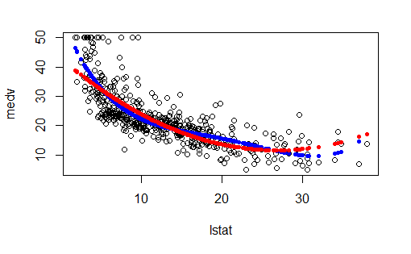

```r
points(lstat,fitted(fit6),col="red",pch=20)
```